# Exporting estimation tables

Laurent Berge

2026-03-17

`fixest` offers a tool, the function `etable`, to view estimation tables in `R` or export them to Latex.

The main advantage of this function is its simplicity: it is completely integrated with other `fixest` functions, making it exceedingly easy to export multiple estimation results with, say, different types of standard-errors. On the other hand, its main limitations are that *i)* only `fixest` objects can be exported, and *ii)* only Latex is supported (although the use of post-processing functions opens up a lot of possibilities).

It also offers a fair deal of customization, and since you can seamlessly change its default values, you can completely transform the style of your tables without modifying a single line of code.

Note that there exists excellent alternatives to export tables, like for instance modelsummary (if you don’t know it already, please do have a look, it’s really great!); but they are less integrated with `fixest` objects, possibly necessitating more lines of code to export the same results.

This document does not describe `etable`’s arguments in details (the help page provides many examples). Rather, it illustrates some features that may be hidden at first sight.

This document applies to `fixest` version 0.10.2 or higher.

## Preliminaries

Throughout this document, we will use data from the *airquality* data base. We also set a dictionary that will be used to rename the variables used in `etable`. This dictionary is set once and for all.

```r
library(fixest)
data(airquality)

# Setting a dictionary
setFixest_dict(c(Ozone = "Ozone (ppb)", Solar.R = "Solar Radiation (Langleys)",
                 Wind = "Wind Speed (mph)", Temp = "Temperature"))
```

## Exporting multiple estimations to data.frames

Let’s estimate the following four models and cluster the standard-errors by `Day`:

```r
# On multiple estimations: see the dedicated vignette
est = feols(Ozone ~ Solar.R + sw0(Wind + Temp) | csw(Month, Day),
            airquality, cluster = ~Day)
```

By default, when the argument `file` is missing, the function `etable` returns a `data.frame`. Let’s see the output of the previous estimations:

```r
etable(est)
```

```
#>                                       est.1            est.2           est.3
#> Dependent Var.:                 Ozone (ppb)      Ozone (ppb)     Ozone (ppb)
#>
#> Solar Radiation (Langleys) 0.115*** (0.023)   0.052* (0.020) 0.108** (0.033)
#> Wind Speed (mph)                            -3.11*** (0.799)
#> Temperature                                  1.88*** (0.367)
#> Fixed-Effects:             ---------------- ---------------- ---------------
#> Month                                   Yes              Yes             Yes
#> Day                                      No               No             Yes
#> __________________________ ________________ ________________ _______________
#> S.E.: Clustered                     by: Day          by: Day         by: Day
#> Observations                            111              111             109
#> R2                                  0.31974          0.63686         0.57983
#> Within R2                           0.12245          0.53154         0.12074
#>
#>                                       est.4
#> Dependent Var.:                 Ozone (ppb)
#>
#> Solar Radiation (Langleys)   0.051* (0.024)
#> Wind Speed (mph)           -3.29*** (0.779)
#> Temperature                 2.05*** (0.242)
#> Fixed-Effects:             ----------------
#> Month                                   Yes
#> Day                                     Yes
#> __________________________ ________________
#> S.E.: Clustered                     by: Day
#> Observations                            109
#> R2                                  0.81588
#> Within R2                           0.61471
#> ---
#> Signif. codes: 0 '***' 0.001 '**' 0.01 '*' 0.05 '.' 0.1 ' ' 1
```

What can we notice? First, the variables are properly labeled. Second, the fixed-effects section details which fixed-effects is included in which model. Third, the type of standard-error is reminded in a dedicated row.

Starting from this table, two elements are detailed: a) how to change the look of the table with the `style.df` argument, b) how to leverage tools from other packages with the `postprocess.df` argument.

### Changing the look of the data.frame with `style.df`

You can change many elements of the `data.frame` with the argument `style.df` whose input must come from the function `style.df`. The style monitors many elements of the table, in particular the titles of the sections. Let’s have an example:

```r
etable(est, style.df = style.df(depvar.title = "", fixef.title = "",
                                fixef.suffix = " fixed effect", yesNo = "yes"))
```

```
#>                                       est.1            est.2           est.3
#>                                 Ozone (ppb)      Ozone (ppb)     Ozone (ppb)
#>
#> Solar Radiation (Langleys) 0.115*** (0.023)   0.052* (0.020) 0.108** (0.033)
#> Wind Speed (mph)                            -3.11*** (0.799)
#> Temperature                                  1.88*** (0.367)
#> Month fixed effect                      yes              yes             yes
#> Day fixed effect                                                         yes
#> __________________________ ________________ ________________ _______________
#> S.E.: Clustered                     by: Day          by: Day         by: Day
#> Observations                            111              111             109
#> R2                                  0.31974          0.63686         0.57983
#> Within R2                           0.12245          0.53154         0.12074
#>
#>                                       est.4
#>                                 Ozone (ppb)
#>
#> Solar Radiation (Langleys)   0.051* (0.024)
#> Wind Speed (mph)           -3.29*** (0.779)
#> Temperature                 2.05*** (0.242)
#> Month fixed effect                      yes
#> Day fixed effect                        yes
#> __________________________ ________________
#> S.E.: Clustered                     by: Day
#> Observations                            109
#> R2                                  0.81588
#> Within R2                           0.61471
#> ---
#> Signif. codes: 0 '***' 0.001 '**' 0.01 '*' 0.05 '.' 0.1 ' ' 1
```

In the previous example, the dependent variable and fixed-effects (FE) headers have been removed, and this is achieved with the (explicit) arguments `depvar.title` and `fixef.title`. Furthermore the suffix `"fixed effect"` is added to each fixed-effect variable, and the indicator of which FE is included in which model is slightly changed. There are more options that are described in the `style.df` documentation.

#### Postprocessing with external functions

Since the output of `etable` is a `data.frame`, any formatting function handling `data.frame`s can be leveraged. It is then very easy to integrate it into `etable`. Let’s have an example with the package `pander`:

```r
library(pander)

etable(est, postprocess.df = pandoc.table.return, style = "rmarkdown")
```

```
#>
#>
#> |           &nbsp;           |      est.1       |      est.2       |
#> |:--------------------------:|:----------------:|:----------------:|
#> |      Dependent Var.:       |   Ozone (ppb)    |   Ozone (ppb)    |
#> |                            |                  |                  |
#> | Solar Radiation (Langleys) | 0.115*** (0.023) |  0.052* (0.020)  |
#> |      Wind Speed (mph)      |                  | -3.11*** (0.799) |
#> |        Temperature         |                  | 1.88*** (0.367)  |
#> |       Fixed-Effects:       | ---------------- | ---------------- |
#> |           Month            |       Yes        |       Yes        |
#> |            Day             |        No        |        No        |
#> | __________________________ | ________________ | ________________ |
#> |      S.E.: Clustered       |     by: Day      |     by: Day      |
#> |        Observations        |       111        |       111        |
#> |             R2             |     0.31974      |     0.63686      |
#> |         Within R2          |     0.12245      |     0.53154      |
#>
#> Table: Table continues below
#>
#>
#>
#> |      est.3      |      est.4       |
#> |:---------------:|:----------------:|
#> |   Ozone (ppb)   |   Ozone (ppb)    |
#> |                 |                  |
#> | 0.108** (0.033) |  0.051* (0.024)  |
#> |                 | -3.29*** (0.779) |
#> |                 | 2.05*** (0.242)  |
#> | --------------- | ---------------- |
#> |       Yes       |       Yes        |
#> |       Yes       |       Yes        |
#> | _______________ | ________________ |
#> |     by: Day     |     by: Day      |
#> |       109       |       109        |
#> |     0.57983     |     0.81588      |
#> |     0.12074     |     0.61471      |
```

What did it do? First, it called the function `pandoc.table.return` from within `etable`. Second, the argument `style` is not from `etable` but is from `pander`’s function. Indeed, all the arguments to the postprocessing function are caught and passed to it. So far so good. But you could say: why bother using the posprocessing function when we could just use piping? You’re right, but wait a second for the next section.

#### Setting `etable` default values

One important feature of `etable` is that you can set the default values of almost all its arguments. This includes the postprocessing function. Let’s change the default values of `style.df` and `postprocess.df`:

```r
my_style = style.df(depvar.title = "", fixef.title = "",
                    fixef.suffix = " fixed effect", yesNo = "yes")
setFixest_etable(style.df = my_style, postprocess.df = pandoc.table.return)
```

Since now `pandoc.table.return` is the default postprocessing, *all its arguments are added to `etable`*. So calls like that are valid even though `style` or `caption` are *not* arguments from `etable`:

```r
etable(est[rhs = 2], style = "rmarkdown", caption = "New default values")
```

```
#>
#>
#> |           &nbsp;           |  est[rhs = 2].1  |  est[rhs = 2].2  |
#> |:--------------------------:|:----------------:|:----------------:|
#> |                            |   Ozone (ppb)    |   Ozone (ppb)    |
#> |                            |                  |                  |
#> | Solar Radiation (Langleys) |  0.052* (0.020)  |  0.051* (0.024)  |
#> |      Wind Speed (mph)      | -3.11*** (0.799) | -3.29*** (0.779) |
#> |        Temperature         | 1.88*** (0.367)  | 2.05*** (0.242)  |
#> |     Month fixed effect     |       yes        |       yes        |
#> |      Day fixed effect      |                  |       yes        |
#> | __________________________ | ________________ | ________________ |
#> |      S.E.: Clustered       |     by: Day      |     by: Day      |
#> |        Observations        |       111        |       109        |
#> |             R2             |     0.63686      |     0.81588      |
#> |         Within R2          |     0.53154      |     0.61471      |
```

## Exporting multiple estimations to Latex

We now illustrate the exports to Latex. First, to include all the sections of a table, let’s add a fifth estimation to the previous example; this new estimation includes variables with varying slopes:

```r
est_slopes = feols(Ozone ~ Solar.R + Wind | Day + Month[Temp], airquality)
```

To export to Latex, use the argument `tex = TRUE` (note that this argument is on when the argument `file` is not missing):

```r
etable(est, est_slopes, tex = TRUE)
```

The previous code produces the following table:

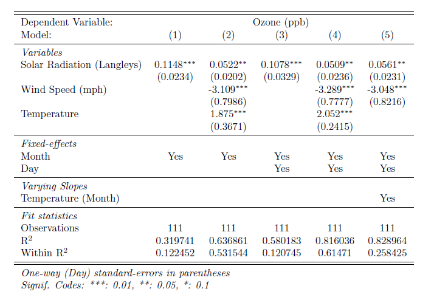

The style of the table is rather sober, but no worries: most of it can be customized. We now illustrate: a) how to change the look of the table with the argument `style.tex`, and how to include custom features with the argument `postproces.tex`.

### Changing the look of the Latex table with `style.tex`

The argument `style.tex` defines how the table looks. It allows an in-depth customization of the table. The table is split into several components, each allowing some customization. The components of a table and some of its associated keywords are described by the following figure:

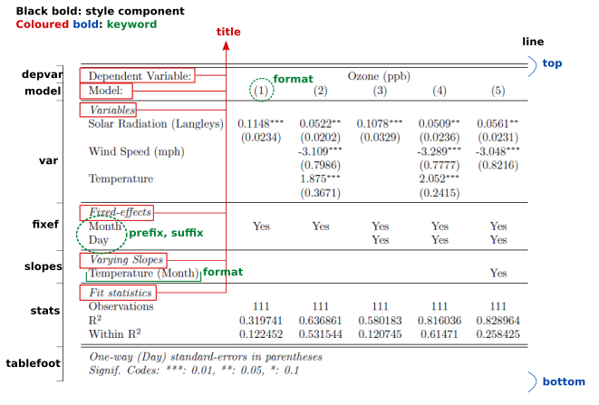

The argument `style.tex` only accepts outputs from the function `style.tex`. That function is documented and describes the different components that can be found in the previous illustration.

The function `style.tex` has two starting points (in the argument `main`), either the style of the first table displayed, either a much more compact style named “aer”. Let’s show the same table with the aer style, without stars beside the coefficients, and different fit statistics:

```r
etable(est, est_slopes, style.tex = style.tex("aer"),
       signif.code = NA, fitstat = ~ r2 + n, tex = TRUE)
```

Which yields the following table:

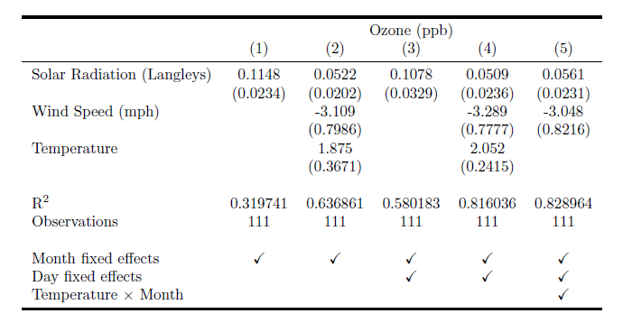

### Adding custom features with `postprocess.tex`

When `tex = TRUE` `etable` returns a character vector. It is possible to modify it at will with the argument `postprocess.tex`. When a postprocessing function is detected, two additional tags are added to the character vector identifying the start and end of the table (`"%start:tab\\n"` and `"%end:tab\\n"`).

Assume we want to set the rule widths of the table, we could write the following function:

```r
set_rules = function(x, heavy, light){
  # x: the character vector returned by etable

  tex2add = ""
  if(!missing(heavy)){
    tex2add = paste0("\\setlength\\heavyrulewidth{", heavy, "}\n")
  }
  if(!missing(light)){
    tex2add = paste0(tex2add, "\\setlength\\lightrulewidth{", light, "}\n")
  }

  if(nchar(tex2add) > 0){
    x[x == "%start:tab\n"] = tex2add
  }

  x
}
```

Now we can summon that function from `etable`:

```r
etable(est, est_slopes, postprocess.tex = set_rules, heavy = "0.14em", tex = TRUE)
```

Of course it is even more convenient to set `set_rules` as the default postprocessing function.

#### Setting `etable` default values: Latex edition

To set the default values, like for the data.frame output, use `setFixest_etable`:

```r
setFixest_etable(style.tex = style.tex("aer", signif.code = NA), postprocess.tex = set_rules,
                 fitstat = ~ r2 + n)
```

Now we can access directly the arguments of the postprocessing function and the default style is the one of the second table:

```r
etable(est, heavy = "0.14em", tex = TRUE)
```

```
#> \begingroup
#> \centering
#> \setlength\heavyrulewidth{0.14em}
#> \begin{tabular}{lcccc}
#>    \toprule
#>     & \multicolumn{4}{c}{Ozone (ppb)}\\
#>                               & (1)           & (2)           & (3)           & (4)\\
#>    \midrule
#>    Solar Radiation (Langleys) & 0.115         & 0.052         & 0.108         & 0.051\\
#>                               & (0.023)       & (0.020)       & (0.033)       & (0.024)\\
#>    Wind Speed (mph)           &               & -3.11         &               & -3.29\\
#>                               &               & (0.799)       &               & (0.779)\\
#>    Temperature                &               & 1.88          &               & 2.05\\
#>                               &               & (0.367)       &               & (0.242)\\
#>     \\
#>    R$^2$                      & 0.31974       & 0.63686       & 0.57983       & 0.81588\\
#>    Observations               & 111           & 111           & 109           & 109\\
#>     \\
#>    Month fixed effects        & $\checkmark$  & $\checkmark$  & $\checkmark$  & $\checkmark$\\
#>    Day fixed effects          &               &               & $\checkmark$  & $\checkmark$\\
#>    \bottomrule
#> \end{tabular}
#> \par\endgroup
```

## Setting custom fit statistics

It is often useful to include in a table some fit statistics that are not standard, or simply that may not be included in `fixest` built-in fit statistics. While it is possible to include any extra line in the table with the argument `extralines`, this is rather cumbersome and possibly error-prone if this task has to be repeated.

To avoid that kind of issue, `fixest` allows the user to register custom fit statistics. Once they are registered, they can be seamlessly called via the `fitstat` argument in `etable`.

Let’s continue with the previous example using the `airquality` data set, and now let’s display different p-values of statistical significance for the variable `Solar.R`. These p-values will vary depending on how we compute the VCOV matrix.

Here is an example that will shortly be explained:

```r
fitstat_register(type = "p_s", alias = "pvalue (standard)",
                 fun = function(x) pvalue(x, vcov = "iid")["Solar.R"])

fitstat_register(type = "p_h", alias = "pvalue (Heterosk.)",
                 fun = function(x) pvalue(x, vcov = "hetero")["Solar.R"])

fitstat_register(type = "p_day", alias = "pvalue (Day)",
                 fun = function(x) pvalue(x, vcov = ~Day)["Solar.R"])

fitstat_register(type = "p_month", alias = "pvalue (Month)",
                 fun = function(x) pvalue(x, vcov = ~Month)["Solar.R"])

# We first reset the default values set in the previous sections
setFixest_etable(reset = TRUE)
# Now we display the results with the new fit statistics
etable(est, fitstat = ~ . + p_s + p_h + p_day + p_month)
```

```
#>                                         est.1              est.2             est.3
#> Dependent Var.:                   Ozone (ppb)        Ozone (ppb)       Ozone (ppb)
#>
#> Solar Radiation (Langleys) 0.1148*** (0.0234)   0.0522* (0.0202) 0.1078** (0.0329)
#> Wind Speed (mph)                              -3.109*** (0.7986)
#> Temperature                                    1.875*** (0.3671)
#> Fixed-Effects:             ------------------ ------------------ -----------------
#> Month                                     Yes                Yes               Yes
#> Day                                        No                 No               Yes
#> __________________________ __________________ __________________ _________________
#> S.E.: Clustered                       by: Day            by: Day           by: Day
#> Observations                              111                111               109
#> R2                                    0.31974            0.63686           0.57983
#> Within R2                             0.12245            0.53154           0.12074
#> pvalue (standard)                     0.00022            0.02957           0.00196
#> pvalue (Heterosk.)                    6.64e-6            0.02268           0.00093
#> pvalue (Day)                             3e-5            0.01468           0.00282
#> pvalue (Month)                        0.06066            0.26992           0.02600
#>
#>                                         est.4
#> Dependent Var.:                   Ozone (ppb)
#>
#> Solar Radiation (Langleys)   0.0509* (0.0236)
#> Wind Speed (mph)           -3.289*** (0.7791)
#> Temperature                 2.052*** (0.2420)
#> Fixed-Effects:             ------------------
#> Month                                     Yes
#> Day                                       Yes
#> __________________________ __________________
#> S.E.: Clustered                       by: Day
#> Observations                              109
#> R2                                    0.81588
#> Within R2                             0.61471
#> pvalue (standard)                     0.03720
#> pvalue (Heterosk.)                    0.02679
#> pvalue (Day)                          0.03973
#> pvalue (Month)                        0.29584
#> ---
#> Signif. codes: 0 '***' 0.001 '**' 0.01 '*' 0.05 '.' 0.1 ' ' 1
```

The function `fitstat_register` is a tool to add fit statistics in the `fitstat` engine. The first argument, `type`, is the code name by which the statistic is to be summoned. The argument `alias` provides the row name of the statistics: how it should look in the table. Finally in the `fun` argument is the function computing the statistic. That function must apply to a `fixest` estimation and must also return a single value.

Once these statistics are registered, they can seamlessly be summoned with the argument `fitstat` and will appear in the order the user provide. Note that the dot in `fitstat = ~ . + p_s + etc` represents the default statistics to be displayed and need not be there.

## Using external functions to export multiple results

Thanks to contributors (namely Karl Dunkle Werner), `fixest` objects are compatible with [broom](https://broom.tidymodels.org/index.html) methods. This means that export functions building on `broom` can be leveraged, like for instance the excellent modelsummary.

In case you use external export tools, here are some tips.

Multiple estimations, like the object `est` in the previous examples, are a bit special and `broom` methods can’t apply directly. To export them, you first need to coerce the results into a list: by simply using `as.list(est)`.

By default in `fixest` the estimations are separated from the calculation of the VCOV matrices. That’s not a problem when using `etable` since, after providing the argument `vcov` or `cluster`, all VCOVs are calculated at once. Using other tools for exportation requires a call to `summary` for each model to compute the appropriate standard-errors. But this process can also be automatized. The function `.l()` can be used to coerce several `fixest` objects to which `summary` can then be applied, for example:

```r
summary(.l(est, est_slopes), cluster = ~ Month)
```

The previous code returns a list of the five estimations for which the standard-errors are all clustered at the Month level, and can then be exported with external software.